# Setup

```r
library(bugsigdbr)
library(gespeR)
library(ggplot2)
library(ontologyIndex)
library(ontologySimilarity)
library(reticulate)
library(BugSigDBStats)
library(EnrichmentPlotter)
```

# Semantic similarity

Semantic similarity measures have been proposed for comparing concepts within an ontology [Schlicker et al., 2006](https://bmcbioinformatics.biomedcentral.com/articles/10.1186/1471-2105-7-302). We therefore treat the NCBI taxonomy as an ontology, and compute semantic similarity between signatures.

```r
onto <- BugSigDBStats::getNcbiTaxonomyObo()
```

```
## Using cached version from 2021-09-12 21:44:53
```

```
## Retrieveing NCBI taxonomy ontology from cache.
```

```r
# onto <- ontologyIndex::get_ontology("http://purl.obolibrary.org/obo/ncbitaxon.obo")
```

```r
onto
```

```
## Ontology with 2334910 terms
##
## format-version: 1.2
## data-version: 2021-06-10
## ontology: ncbitaxon
##
## Properties:
##  id: character
##  name: character
##  parents: list
##  children: list
##  ancestors: list
##  obsolete: logical
## Roots:
##  NCBITaxon:taxonomic_rank - taxonomic rank
##  NCBITaxon:1 - root
```

```r
head(onto$id)
```

```
##         NCBITaxon:1        NCBITaxon:10       NCBITaxon:100    NCBITaxon:100000
##       "NCBITaxon:1"      "NCBITaxon:10"     "NCBITaxon:100"  "NCBITaxon:100000"
##   NCBITaxon:1000000   NCBITaxon:1000001
## "NCBITaxon:1000000" "NCBITaxon:1000001"
```

One challenge here is that this needs quite some memory (kills your GHA):

```r
pryr::object_size(onto)
```

```
## 1,299,790,096 B
```

We add the corresponding ID prefix:

```r
dat <- bugsigdbr::importBugSigDB()
dat[["Body site"]] <- tolower(dat[["Body site"]])
dat.feces <- subset(dat, `Body site` == "feces")
ind <- lengths(dat.feces[["NCBI Taxonomy IDs"]]) > 4
dat.feces.5 <- dat.feces[ind,]
sigs <- bugsigdbr::getSignatures(dat.feces.5, tax.id.type = "ncbi")
```

We remove taxa that are not in the NCBI Taxonomy:

```r
sigs <- BugSigDBStats::syncWithNCBI(sigs, onto)
```

Now, we compute pairwise semantic similarity for all signatures (which is reasonably fast btw):

```r
system.time(
    sim.mat <- ontologySimilarity::get_sim_grid(ontology = onto, term_sets = sigs)
)
```

```
##    user  system elapsed
##   6.302   0.497   6.789
```

```r
dim(sim.mat)
```

```
## [1] 518 518
```

```r
sim.mat[1:5,1:5]
```

```
##                                                                           bsdb:1/1/1_adenoma:conventional-adenoma-cases_vs_controls_UP
## bsdb:1/1/1_adenoma:conventional-adenoma-cases_vs_controls_UP                                                                 1.0000000
## bsdb:1/4/1_adenoma:Proximal-conventional-adenoma-cases_vs_controls_UP                                                        0.9152300
## bsdb:1/5/1_adenoma:Distal-conventional-adenoma-cases_vs_controls_DOWN                                                        0.5712941
## bsdb:1/6/1_adenoma:Non-advanced-conventional-adenoma-cases_vs_controls_UP                                                    0.8915920
## bsdb:1/7/1_adenoma:advanced-conventional-adenoma-cases_vs_controls_UP                                                        0.6934028
##                                                                           bsdb:1/4/1_adenoma:Proximal-conventional-adenoma-cases_vs_controls_UP
## bsdb:1/1/1_adenoma:conventional-adenoma-cases_vs_controls_UP                                                                          0.9152300
## bsdb:1/4/1_adenoma:Proximal-conventional-adenoma-cases_vs_controls_UP                                                                 1.0000000
## bsdb:1/5/1_adenoma:Distal-conventional-adenoma-cases_vs_controls_DOWN                                                                 0.6126876
## bsdb:1/6/1_adenoma:Non-advanced-conventional-adenoma-cases_vs_controls_UP                                                             0.8768852
## bsdb:1/7/1_adenoma:advanced-conventional-adenoma-cases_vs_controls_UP                                                                 0.7615430
##                                                                           bsdb:1/5/1_adenoma:Distal-conventional-adenoma-cases_vs_controls_DOWN
## bsdb:1/1/1_adenoma:conventional-adenoma-cases_vs_controls_UP                                                                          0.5712941
## bsdb:1/4/1_adenoma:Proximal-conventional-adenoma-cases_vs_controls_UP                                                                 0.6126876
## bsdb:1/5/1_adenoma:Distal-conventional-adenoma-cases_vs_controls_DOWN                                                                 1.0000000
## bsdb:1/6/1_adenoma:Non-advanced-conventional-adenoma-cases_vs_controls_UP                                                             0.5796675
## bsdb:1/7/1_adenoma:advanced-conventional-adenoma-cases_vs_controls_UP                                                                 0.3558267
##                                                                           bsdb:1/6/1_adenoma:Non-advanced-conventional-adenoma-cases_vs_controls_UP
## bsdb:1/1/1_adenoma:conventional-adenoma-cases_vs_controls_UP                                                                              0.8915920
## bsdb:1/4/1_adenoma:Proximal-conventional-adenoma-cases_vs_controls_UP                                                                     0.8768852
## bsdb:1/5/1_adenoma:Distal-conventional-adenoma-cases_vs_controls_DOWN                                                                     0.5796675
## bsdb:1/6/1_adenoma:Non-advanced-conventional-adenoma-cases_vs_controls_UP                                                                 1.0000000
## bsdb:1/7/1_adenoma:advanced-conventional-adenoma-cases_vs_controls_UP                                                                     0.4988249
##                                                                           bsdb:1/7/1_adenoma:advanced-conventional-adenoma-cases_vs_controls_UP
## bsdb:1/1/1_adenoma:conventional-adenoma-cases_vs_controls_UP                                                                          0.6934028
## bsdb:1/4/1_adenoma:Proximal-conventional-adenoma-cases_vs_controls_UP                                                                 0.7615430
## bsdb:1/5/1_adenoma:Distal-conventional-adenoma-cases_vs_controls_DOWN                                                                 0.3558267
## bsdb:1/6/1_adenoma:Non-advanced-conventional-adenoma-cases_vs_controls_UP                                                             0.4988249
## bsdb:1/7/1_adenoma:advanced-conventional-adenoma-cases_vs_controls_UP                                                                 1.0000000
```

```r
summary(as.vector(sim.mat))
```

```
##     Min.  1st Qu.   Median     Mean  3rd Qu.     Max.
## 0.008994 0.411645 0.504003 0.499275 0.593168 1.000000
```

Given the matrix of pairwise semantic similarity between signatures, we can also compute the semantic similarity of a group of signatures by eg. taking the average similarity between all pairs of signatures.

Here, we compute the semantic similarity of all colorectal cancer signatures in the database for which abundance is increased in the cases.

```r
ind <- !is.na(dat.feces.5[["Condition"]]) &
       dat.feces.5[["Condition"]] == "colorectal cancer" &
       dat.feces.5[["Body site"]] == "feces" &
       dat.feces.5[["Abundance in Group 1"]] == "increased"
sum(ind)
```

```
## [1] 11
```

```r
ontologySimilarity::get_sim(sim.mat, group = which(ind))
```

```
## [1] 0.5701859
```

Furthermore, we can compute a p-value for assessing the statistical significance of the similiarity of a group of signatures. The p-value is calculated by random sampling of groups of the same size as `group`, and calculating how many random groups have at least as great group similarity than does `group`.

```r
ontologySimilarity::get_sim_p(sim.mat, group = which(ind))
```

```
## [1] 0.04400956
```

Cluster similarity and visualize signature:

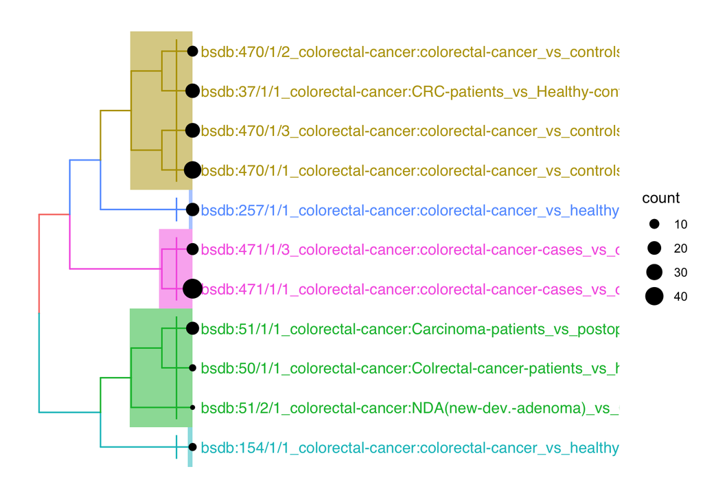

```r
EnrichmentPlotter::treeSimPlot(sigs[ind], sim.mat[ind,ind])
```

Chunk up entire BugSigDB by body site:

```r
spl <- bugsigdbr::getMetaSignatures(dat, column = "Body site")
spl <- lapply(spl, names)
```

Calculate semantic similarity between body site chunked-up signatures:

```r
spl <- BugSigDBStats::syncWithNCBI(spl, onto)
sm.bs <- ontologySimilarity::get_sim_grid(ontology = onto, term_sets = spl)
sm.bs[1:5,1:5]
```

```
##                   blood    breast buccal mucosa    caecum     colon
## blood         1.0000000 0.6536731     0.6730674 0.6424804 0.7095916
## breast        0.6536731 1.0000000     0.5963237 0.4916656 0.5971903
## buccal mucosa 0.6730674 0.5963237     1.0000000 0.6107334 0.6905501
## caecum        0.6424804 0.4916656     0.6107334 1.0000000 0.7334932
## colon         0.7095916 0.5971903     0.6905501 0.7334932 1.0000000
```

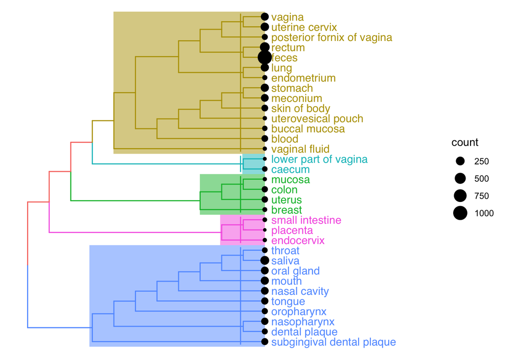

```r
bsp <- EnrichmentPlotter::treeSimPlot(spl, sm.bs)
bsp
```

Do the same for jaccard:

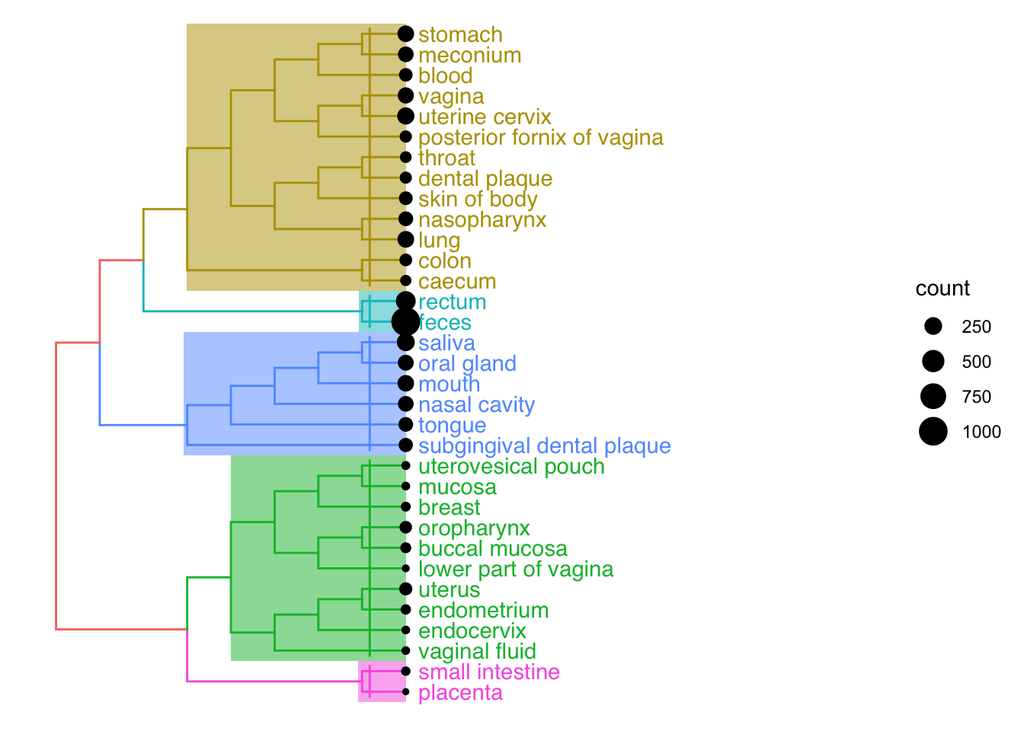

```r
spl <- bugsigdbr::getMetaSignatures(dat, column = "Body site",
                                    tax.id.type = "metaphlan")
spl <- lapply(spl, names)
sm.bs <- BugSigDBStats::calcJaccardSimilarity(spl)
bsp.jacc <- EnrichmentPlotter::treeSimPlot(spl, sm.bs)
bsp.jacc
```

Take a closer look at nasal cavity signatures:

```r
ndat <- subset(dat, `Body site` == "nasal cavity")
nms <- sort(unique(unlist(ndat[["MetaPhlAn taxon names"]])))
dim(ndat)
```

```
## [1] 32 48
```

```r
unique(ndat$PMID)
```

```
## [1] 21188149 29518419 31201890       NA
```

Compare nasal cavity meta-signature to feces meta-signature:

```r
fdat <- subset(dat, `Body site` == "feces")
fms <- sort(unique(unlist(fdat[["MetaPhlAn taxon names"]])))
table(nms %in% fms)
```

```
##
## FALSE  TRUE
##    69    99
```

Check whether remaining nasal cavity taxa are in feces meta-signature at family level:

```r
nnms <- nms[!(nms %in% fms)]
nnms.fam <- bugsigdbr::extractTaxLevel(nnms, tax.level = "family", exact.tax.level = FALSE)
fms.fam <- bugsigdbr::extractTaxLevel(fms, tax.level = "family", exact.tax.level = FALSE)
table(nnms.fam %in% fms.fam)
```

[output not shown]

Meta-signatures by condition:

```r
dat.feces <- subset(dat, `Body site` == "feces")
spl <- bugsigdbr::getMetaSignatures(dat.feces,
                                    column = "Condition",
                                    direction = "UP")
spl <- lapply(spl, names)
```

Calculate semantic similarity between condition meta-signatures:

```r
spl <- BugSigDBStats::syncWithNCBI(spl, onto)
sm.bs <- ontologySimilarity::get_sim_grid(ontology = onto, term_sets = spl)
sm.bs[1:5,1:5]
```

```
##                              acute lymphoblastic leukemia       age
## acute lymphoblastic leukemia                    1.0000000 0.6288985
## age                                             0.6288985 1.0000000
## air pollution                                   0.5528809 0.5609034
## anorexia nervosa                                0.8006407 0.5957738
## antimicrobial agent                             0.7909111 0.6702080
##                              air pollution anorexia nervosa antimicrobial agent
## acute lymphoblastic leukemia     0.5528809        0.8006407           0.7909111
## age                              0.5609034        0.5957738           0.6702080
## air pollution                    1.0000000        0.5145096           0.5495446
## anorexia nervosa                 0.5145096        1.0000000           0.7470818
## antimicrobial agent              0.5495446        0.7470818           1.0000000
```

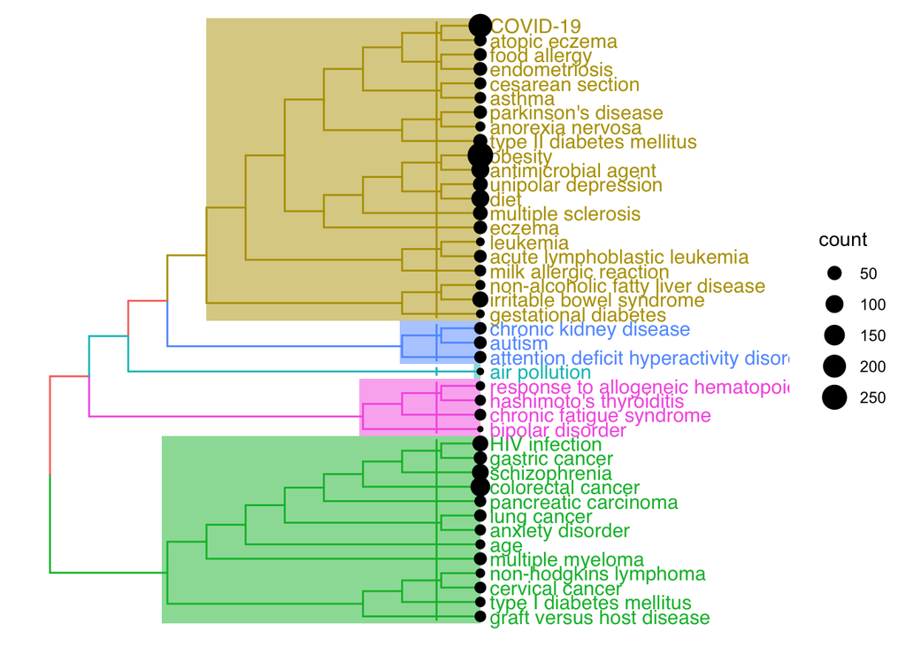

```r
cop <- EnrichmentPlotter::treeSimPlot(spl, sm.bs)
cop
```

Do the same for jaccard:

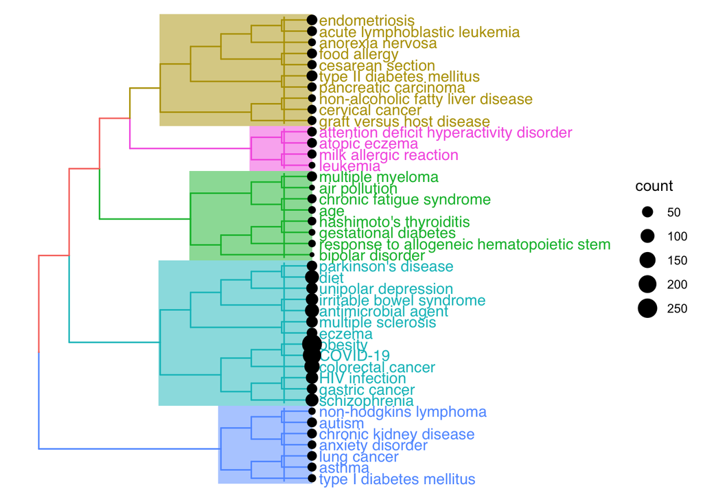

```r
spl <- bugsigdbr::getMetaSignatures(dat.feces,
                                    column = "Condition",
                                    direction = "UP",
                                    tax.id.type = "metaphlan")
spl <- lapply(spl, names)
sm.bs <- BugSigDBStats::calcJaccardSimilarity(spl)
cop.jacc <- EnrichmentPlotter::treeSimPlot(spl, sm.bs)
cop.jacc
```

# Weighted meta-signatures

## Weighted semantic similarity

Obtain weighted meta-signatures for body sites:

```r
bs.meta.sigs <- bugsigdbr::getMetaSignatures(dat, column = "Body site")
```

Calculate weighted semantic similarity between between meta-signatures:

```r
ic <- ontologySimilarity::descendants_IC(onto)
spl <- bs.meta.sigs
```

```r
.syncWithNCBI2 <- function(spl, onto)
{
    for(i in seq_along(spl)) names(spl[[i]]) <- paste0("NCBITaxon:", names(spl[[i]]))
    utax <- unique(names(unlist(spl)))
    nt <- utax[!(utax %in% onto$id)]
    spl <- lapply(spl, function(s) s[setdiff(names(s), nt)])
    return(spl)
}
spl <- .syncWithNCBI2(spl, onto)
```

```r
.wsm <- function(x) BugSigDBStats::weightedBMA(onto, ic,
                                               names(spl[[x[1]]]), names(spl[[x[2]]]),
                                               unname(spl[[x[1]]]), unname(spl[[x[2]]]))

.getAdjMat <- function(spl, func)
{
    combs <- combn(names(spl), 2)
    wsm.bs <- apply(combs, 2, func)
    wsm.df <- data.frame(c1 = combs[1,], c2 = combs[2,], wsm = wsm.bs)
    ig <- igraph::graph_from_data_frame(wsm.df, directed = FALSE)
    adjm <- igraph::get.adjacency(ig, attr = "wsm", sparse = FALSE)
    diag(adjm) <- 1
    return(adjm)
}

adjm <- .getAdjMat(spl, .wsm)
adjm[1:5,1:5]
```

```
##                   blood    breast buccal mucosa    caecum     colon
## blood         1.0000000 0.6046227     0.6977796 0.6753457 0.7261330
## breast        0.6046227 1.0000000     0.5492520 0.4521133 0.5558178
## buccal mucosa 0.6977796 0.5492520     1.0000000 0.6439389 0.7240121
## caecum        0.6753457 0.4521133     0.6439389 1.0000000 0.7401935
## colon         0.7261330 0.5558178     0.7240121 0.7401935 1.0000000
```

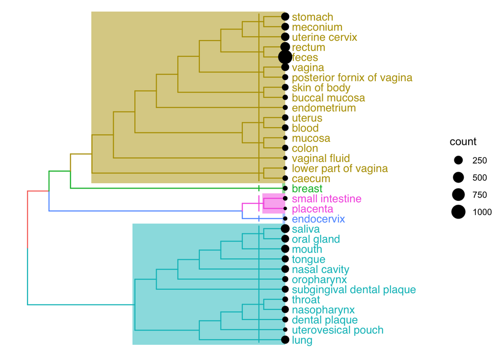

```r
wbsp <- EnrichmentPlotter::treeSimPlot(spl, adjm)
wbsp
```

Obtain weighted meta-signatures for condition from fecal samples:

```r
co.meta.sigs <- bugsigdbr::getMetaSignatures(dat.feces,
                                             column = "Condition",
                                             direction = "UP")
```

Calculate weighted semantic similarity between between meta-signatures:

```r
spl <- co.meta.sigs
spl <- .syncWithNCBI2(spl, onto)
adjm <- .getAdjMat(spl, .wsm)
adjm[1:5,1:5]
```

```
##                              acute lymphoblastic leukemia       age
## acute lymphoblastic leukemia                    1.0000000 0.6574768
## age                                             0.6574768 1.0000000
## air pollution                                   0.5507980 0.5400584
## anorexia nervosa                                0.8451610 0.5850472
## antimicrobial agent                             0.8140857 0.6778403
##                              air pollution anorexia nervosa antimicrobial agent
## acute lymphoblastic leukemia     0.5507980        0.8451610           0.8140857
## age                              0.5400584        0.5850472           0.6778403
## air pollution                    1.0000000        0.5455678           0.5383957
## anorexia nervosa                 0.5455678        1.0000000           0.7539737
## antimicrobial agent              0.5383957        0.7539737           1.0000000
```

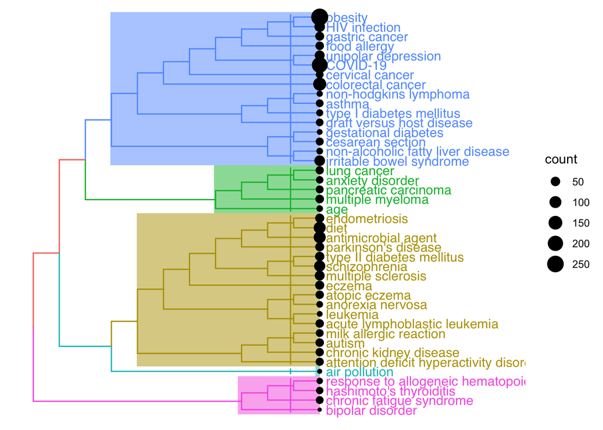

```r
wcop <- EnrichmentPlotter::treeSimPlot(spl, adjm)
wcop
```

## Rank-biased overlap (RBO)

[Rank-biased overlap (RBO)](http://w.codalism.com/research/papers/wmz10_tois.pdf) is a measure for the similarity of two potentially incomplete rankings that handles non-conjointness, weighs high ranks more heavily than low ranks, and is monotonic with increasing depth of evaluation.

As explained in this [excellent post](https://towardsdatascience.com/rbo-v-s-kendall-tau-to-compare-ranked-lists-of-items-8776c5182899), RBO thus resolves some of the drawbacks that would be encountered when applying traditional rank-based correlation (eg. Spearman or Kendall) that work best for conjoint rankings.

There are (at least) two existing and somewhat plausible implementations of RBO:

1. An R implementation in the gespeR package,
2. A Python implementation in this rbo github repo.

Here, we try out both of them for genus-level meta-signatures for body sites and conditions.

```r
# importing python package from https://github.com/changyaochen/rbo via reticulate
rbo <- reticulate::import("rbo")
```

Obtain weighted meta-signatures for body sites harmonized to genus level:

```r
bs.meta.sigs.genus <- bugsigdbr::getMetaSignatures(dat,
                                             column = "Body site",
                                             tax.id.type = "taxname",
                                             tax.level = "genus",
                                             exact.tax.level = FALSE)
```

Apply both RBO implementations for all body-site combinations, and check for agreement in results:

```r
combs <- combn(names(bs.meta.sigs.genus), 2)
rrbo <- function(x) gespeR::rbo(bs.meta.sigs.genus[[x[1]]],
                                bs.meta.sigs.genus[[x[2]]],
                                p = 1)
pyrbo <- function(x) rbo$RankingSimilarity(
                        names(bs.meta.sigs.genus[[x[1]]]),
                        names(bs.meta.sigs.genus[[x[2]]]))$rbo()
rrbo.bs <- apply(combs, 2, rrbo)
pyrbo.bs <- apply(combs, 2, pyrbo)
cor(rrbo.bs, pyrbo.bs)
```

```
## [1] 0.8112021
```

RBO similarity (R implementation):

```r
adjm <- .getAdjMat(bs.meta.sigs.genus, rrbo)
adjm[1:5,1:5]
```

```
##                   blood     breast buccal mucosa     caecum      colon
## blood         1.0000000 0.19047619    0.18181818 0.14354067 0.13333333
## breast        0.1904762 1.00000000    0.05263158 0.00000000 0.06666667
## buccal mucosa 0.1818182 0.05263158    1.00000000 0.15789474 0.21052632
## caecum        0.1435407 0.00000000    0.15789474 1.00000000 0.06666667
## colon         0.1333333 0.06666667    0.21052632 0.06666667 1.00000000
```

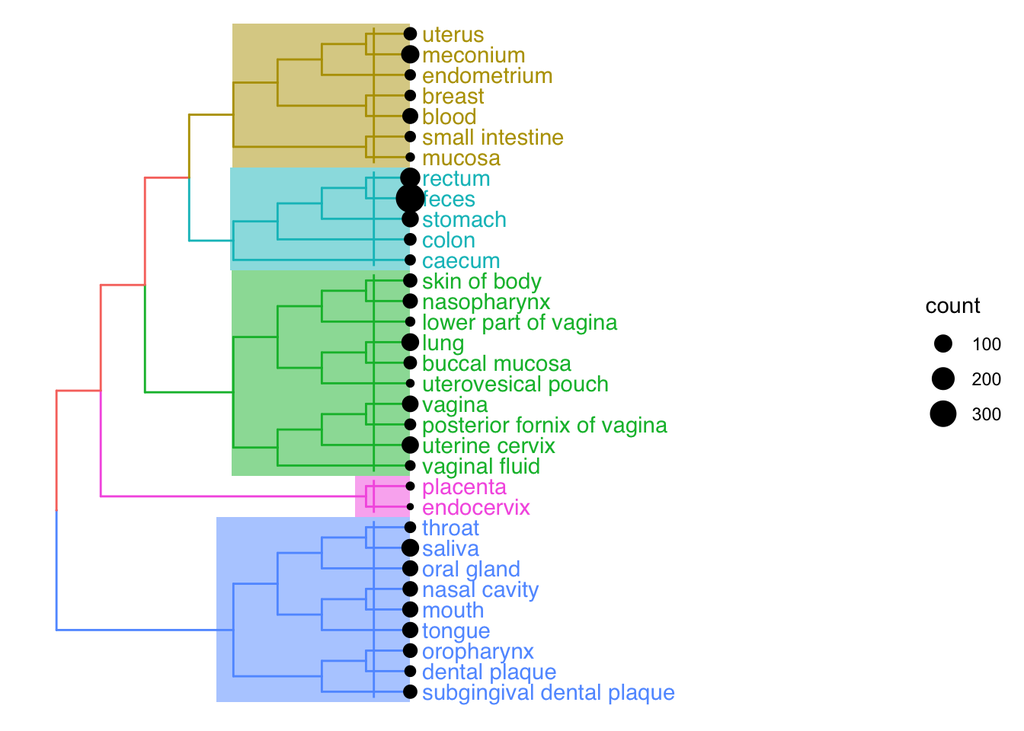

```r
rrbsp <- EnrichmentPlotter::treeSimPlot(bs.meta.sigs.genus, adjm)
rrbsp
```

RBO similarity (Python implementation):

```r
adjm <- .getAdjMat(bs.meta.sigs.genus, pyrbo)
adjm[1:5,1:5]
```

```
##                     blood     breast buccal mucosa      caecum      colon
## blood         1.000000000 0.14433461    0.13532399 0.002770083 0.03327555
## breast        0.144334614 1.00000000    0.04114331 0.000000000 0.05583082
## buccal mucosa 0.135323988 0.04114331    1.00000000 0.255783455 0.15888198
## caecum        0.002770083 0.00000000    0.25578345 1.000000000 0.06198909
## colon         0.033275547 0.05583082    0.15888198 0.061989091 1.00000000
```

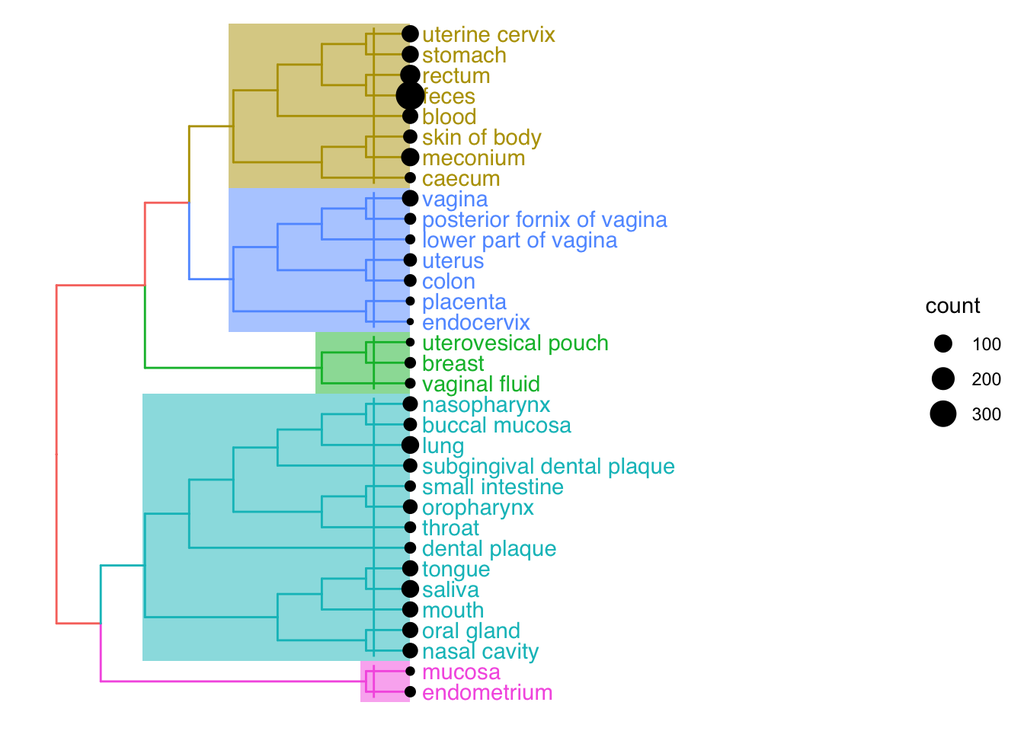

```r
pyrbsp <- EnrichmentPlotter::treeSimPlot(bs.meta.sigs.genus, adjm)
pyrbsp
```

Condition meta-signatures for fecal samples harmonized to genus level:

```r
co.meta.sigs.genus <- bugsigdbr::getMetaSignatures(dat.feces,
                                                   column = "Condition",
                                                   direction = "UP",
                                                   tax.id.type = "taxname",
                                                   tax.level = "genus",
                                                   exact.tax.level = FALSE)
```

RBO similarity (R implementation):

```r
rrbo <- function(x) gespeR::rbo(co.meta.sigs.genus[[x[1]]],
                                co.meta.sigs.genus[[x[2]]],
                                p = 1)
adjm <- .getAdjMat(co.meta.sigs.genus, rrbo)
adjm[1:5,1:5]
```

```
##                              acute lymphoblastic leukemia       age
## acute lymphoblastic leukemia                     1.000000 0.0000000
## age                                              0.000000 1.0000000
## anorexia nervosa                                 0.200000 0.0000000
## antimicrobial agent                              0.317037 0.1509972
## anxiety disorder                                 0.100000 0.1666667
##                              anorexia nervosa antimicrobial agent
## acute lymphoblastic leukemia        0.2000000           0.3170370
## age                                 0.0000000           0.1509972
## anorexia nervosa                    1.0000000           0.2111111
## antimicrobial agent                 0.2111111           1.0000000
## anxiety disorder                    0.0000000           0.2370370
##                              anxiety disorder
## acute lymphoblastic leukemia        0.1000000
## age                                 0.1666667
## anorexia nervosa                    0.0000000
## antimicrobial agent                 0.2370370
## anxiety disorder                    1.0000000
```

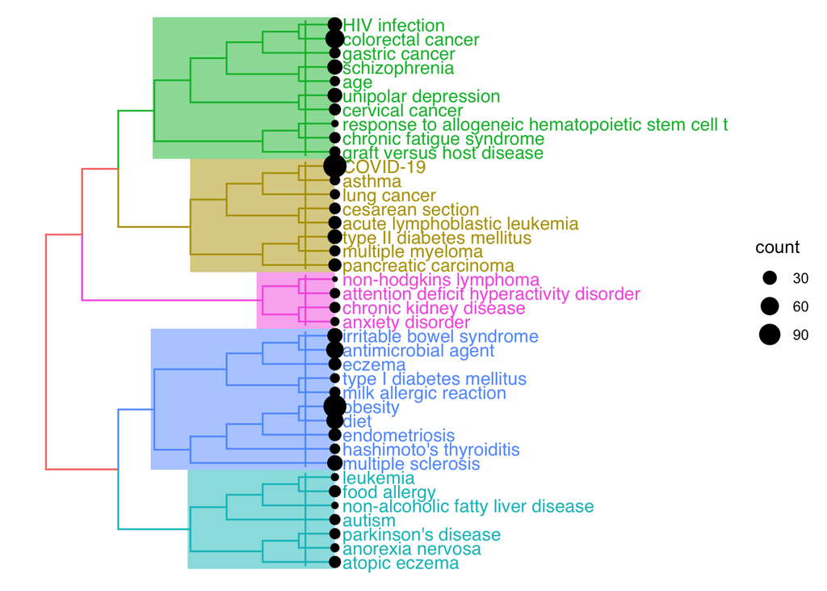

```r
rrcop <- EnrichmentPlotter::treeSimPlot(co.meta.sigs.genus, adjm)
rrcop
```

RBO similarity (Python implementation):

```r
pyrbo <- function(x) rbo$RankingSimilarity(
                        names(co.meta.sigs.genus[[x[1]]]),
                        names(co.meta.sigs.genus[[x[2]]]))$rbo()
adjm <- .getAdjMat(co.meta.sigs.genus, pyrbo)
adjm[1:5,1:5]
```

```
##                              acute lymphoblastic leukemia        age
## acute lymphoblastic leukemia                   1.00000000 0.00000000
## age                                            0.00000000 1.00000000
## anorexia nervosa                               0.05789683 0.03361111
## antimicrobial agent                            0.09980986 0.01932042
## anxiety disorder                               0.03361111 0.11956349
##                              anorexia nervosa antimicrobial agent
## acute lymphoblastic leukemia       0.05789683          0.09980986
## age                                0.03361111          0.01932042
## anorexia nervosa                   1.00000000          0.10956349
## antimicrobial agent                0.10956349          1.00000000
## anxiety disorder                   0.04361111          0.06722222
##                              anxiety disorder
## acute lymphoblastic leukemia       0.03361111
## age                                0.11956349
## anorexia nervosa                   0.04361111
## antimicrobial agent                0.06722222
## anxiety disorder                   1.00000000
```

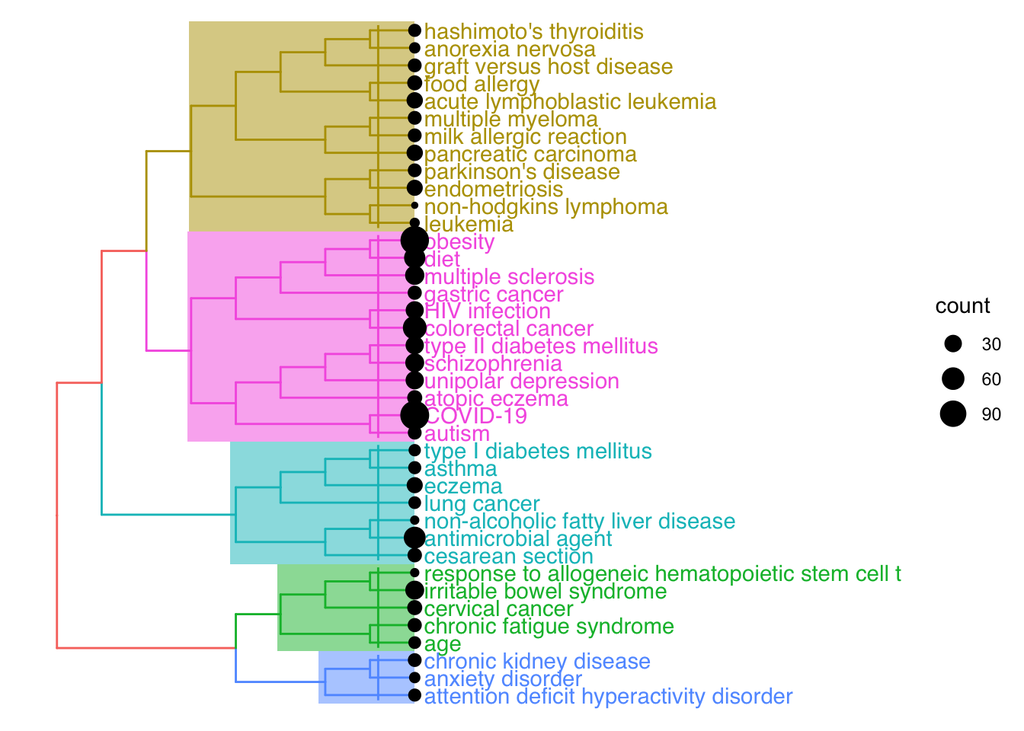

```r
pyrcop <- EnrichmentPlotter::treeSimPlot(co.meta.sigs.genus, adjm)
pyrcop
```